# Clase 1. Carga y Limpieza de Datos

Jairo Enrique Alba

2026-05-08

# 1 1. Definición del problema

Se dispone de un dataset con información sociodemográfica de individuos (edad, ingreso, nivel educativo, profesión, entre otros), el cual presenta múltiples problemas de calidad como:

- Datos faltantes
- Registros duplicados
- Inconsistencias en variables categóricas
- Valores atípicos (outliers)
- Datos erróneos (por ejemplo, ingresos negativos o edades irreales)

El problema consiste en:

**Preparar y transformar el dataset para que sea apto para el entrenamiento de modelos de machine learning que apoyen la toma de decisiones**.

# 2 2. Objetivo general

Desarrollar un proceso completo de limpieza, transformación y preparación de datos que permita construir un dataset confiable y adecuado para aplicar técnicas de aprendizaje automático.

# 3 3. Objetivos específicos

3.1 Identificar problemas de calidad de datos

- Detectar valores faltantes, duplicados e inconsistencias.

3.2. Realizar limpieza de datos

- Tratar valores nulos.
- Eliminar o corregir registros erróneos.
- Gestionar datos atípicos.

3.3 Estandarizar variables

- Unificar formatos de texto (mayúsculas/minúsculas).
- Normalizar categorías (género, ciudad, estado civil).

3.4 Transformar variables

- Codificar variables categóricas (One-Hot, Ordinal).
- Escalar variables numéricas.

3.5 Realizar ingeniería de características

- Crear nuevas variables (ej. ingreso per cápita, nombre completo).
- Seleccionar variables relevantes.

3.6 Preparar el dataset final

- Dividir en entrenamiento y prueba.

3.7 Exportar datos

# 4 4. Cargar los Datos

Verificar que se tienen el archivo a trabajar en la carpeta Datos

```r
list.files("../Datos") # Verificar que archivos están en el proyecto
```

```
## [1] "dataset_clase_1.csv"
```

```r
library(readr)# para leer archivos excel, csv
#library(data.table)#
library(dplyr)
data <- read.csv("C:\\Users\\Jairo\\Desktop\\Clase_1_especializacion\\Datos\\dataset_clase_1.csv")
```

Visyalizar los datos:

```r
# data
```

# 5 4. Exploración de los Datos

```r
tail(data) # últimos datos
```

```
##    ID  Nombre Apellido Edad Ingreso    Genero   Ciudad     Profesion
## 25 25 Natalia    Reyes   23    1000  Femenino     Cali    Estudiante
## 26 26   Oscar      Gil   37    1700 MASCULINO Medellín Administrador
## 27 27 Claudia    Pardo   34    1550  FEMENINO   Bogotá       Docente
## 28 28 Ricardo   Acosta  200    3000 MASCULINO     Cali    Empresario
## 29 29    Lina Bautista   28    1300  Femenino Medellín    Diseñadora
## 30 30    Juan    Pérez   25    1200 MASCULINO   Bogotá     Ingeniero
##    Nivel_Educativo Estado_Civil Hijos             Email
## 25   Universitario      Soltera     0 natalia@gmail.com
## 26   Universitario       Casado     2   oscar@gmail.com
## 27 Especialización       Casada     1 claudia@gmail.com
## 28        Maestría       Casado     4 ricardo@gmail.com
## 29   Universitario      Soltera     0    lina@gmail.com
## 30   Universitario      SOLTERO     0   juanp@gmail.com
```

```r
head(data) # primeros datos
```

```
##   ID Nombre  Apellido Edad Ingreso    Genero   Ciudad   Profesion
## 1  1   Juan     Pérez   25    1200 MASCULINO   Bogotá   Ingeniero
## 2  2    Ana     Gómez   30    1500  Femenino Medellín     Abogada
## 3  3 Carlos     Lopez   45    3000 MASCULINO     Cali      Medico
## 4  4  María Rodríguez   29      NA  FEMENINO   Bogotá     Docente
## 5  5  Pedro  Martinez   35   -2000 Masculino   bogotá Comerciante
## 6  6  Luisa Hernandez   NA    1800  FEMENINO     Cali   Ingeniera
##   Nivel_Educativo Estado_Civil Hijos               Email
## 1   Universitario      SOLTERO     0     juanp@gmail.com
## 2 Especialización       Casada     1 ana.gomez@gmail.com
## 3        Maestría       CASADO     2   carlosl@gmail.com
## 4   Universitario      Soltera     0     maria@gmail.com
## 5       Bachiller  UNION LIBRE     3     pedro@gmail.com
## 6   Universitario      Soltera     0     luisa@gmail.com
```

## 5.1 Dimensiones del archivo.

```r
dim(data)
```

```
## [1] 30 12
```

El archivo tiene tiene 30 registros y 12 columnas(variables)

## 5.2 Conocer el nombre de las columnas (variables)

```r
colnames(data)
```

```
##  [1] "ID"              "Nombre"          "Apellido"        "Edad"
##  [5] "Ingreso"         "Genero"          "Ciudad"          "Profesion"
##  [9] "Nivel_Educativo" "Estado_Civil"    "Hijos"           "Email"
```

## 5.3 Estructura de los datos

```r
str(data)
```

```
## 'data.frame':    30 obs. of  12 variables:
##  $ ID             : int  1 2 3 4 5 6 7 8 9 10 ...
##  $ Nombre         : chr  "Juan" "Ana" "Carlos" "María" ...
##  $ Apellido       : chr  "Pérez" "Gómez" "Lopez" "Rodríguez" ...
##  $ Edad           : num  25 30 45 29 35 NA 25 40 22 28 ...
##  $ Ingreso        : num  1200 1500 3000 NA -2000 1800 1200 50000 1100 1300 ...
##  $ Genero         : chr  "MASCULINO" "Femenino" "MASCULINO" "FEMENINO" ...
##  $ Ciudad         : chr  "Bogotá" "Medellín" "Cali" "Bogotá" ...
##  $ Profesion      : chr  "Ingeniero" "Abogada" "Medico" "Docente" ...
##  $ Nivel_Educativo: chr  "Universitario" "Especialización" "Maestría" "Universitario" ...
##  $ Estado_Civil   : chr  "SOLTERO" "Casada" "CASADO" "Soltera" ...
##  $ Hijos          : int  0 1 2 0 3 0 0 2 0 0 ...
##  $ Email          : chr  "juanp@gmail.com" "ana.gomez@gmail.com" "carlosl@gmail.com" "maria@gmail.com" ...
```

El conjunto de datos contiene 30 observaciones y 12 variables, combinando información numérica y categórica sobre características demográficas, económicas y sociales de las personas registradas. Entre las variables cuantitativas se encuentran la edad, el ingreso y el número de hijos, mientras que las variables cualitativas incluyen género, ciudad, profesión, nivel educativo y estado civil. La estructura muestra que existen algunos valores perdidos en variables como edad e ingreso, además de inconsistencias en la escritura de categorías, por ejemplo diferencias entre mayúsculas y minúsculas (“MASCULINO” y “Masculino”) y variaciones en acentos. También se observan posibles valores atípicos, como una edad de 200 años y un ingreso de 50000, que podrían afectar el análisis estadístico. En general, la base es adecuada para aplicar procesos de limpieza, transformación y análisis exploratorio de datos, permitiendo estudiar patrones relacionados con características personales, económicas y educativas de la población registrada.

```r
freq_profesion <- table(data$Profesion)

freq_profesion
```

```
##
##       Abogada Administrador   Comerciante      Contador    Diseñadora
##             2             2             2             2             2
##       Docente    Empresario    Estudiante     Ingeniera     Ingeniero
##             3             2             3             1             8
##        Medico     Psicologa
##             1             2
```

```r
tabla_profesion <- data.frame(sort(table(data$Profesion),
                                      decreasing = TRUE))

colnames(tabla_profesion) <- c("Profesion", "Frecuencia")

tabla_profesion
```

```
##        Profesion Frecuencia
## 1      Ingeniero          8
## 2        Docente          3
## 3     Estudiante          3
## 4        Abogada          2
## 5  Administrador          2
## 6    Comerciante          2
## 7       Contador          2
## 8     Diseñadora          2
## 9     Empresario          2
## 10     Psicologa          2
## 11     Ingeniera          1
## 12        Medico          1
```

La variable Profesión presenta una alta diversidad ocupacional, siendo Ingeniero la profesión más frecuente con 8 registros, lo que indica un predominio del área de ingeniería dentro del conjunto de datos. Otras profesiones con presencia moderada son Docente y Estudiante, con 3 registros cada una. Además, varias categorías aparecen con frecuencias similares, como Abogada, Administrador, Comerciante, Contador, Diseñadora, Empresario y Psicóloga, cada una con 2 observaciones. También se identifican profesiones con una sola aparición, como Ingeniera y Médico. **Se observa una posible inconsistencia en la variable debido al uso de formas masculinas y femeninas para una misma profesión, por ejemplo, Ingeniero e Ingeniera,** lo que sugiere la necesidad de estandarizar las categorías antes de realizar análisis más precisos.

```r
tabla_genero<- as.data.frame(sort(table(data$Genero),
                                      decreasing = TRUE)) # convertir en data frame

colnames(tabla_genero) <- c("Genero", "Frecuencia")#colocar rótulos a la tabla

tabla_genero
```

```
##      Genero Frecuencia
## 1 MASCULINO         16
## 2  Femenino          8
## 3  FEMENINO          5
## 4 Masculino          1
```

La variable Género presenta inconsistencias en la forma de registrar las categorías, ya que aparecen diferencias en el uso de mayúsculas y minúsculas. La categoría más frecuente es MASCULINO con 16 registros, seguida de Femenino con 8 y FEMENINO con 5. Además, aparece un registro como Masculino con 1 observación. Esto evidencia **problemas de estandarización en los datos, puesto que categorías equivalentes están siendo tratadas como diferentes.** Antes de realizar análisis estadísticos o visualizaciones, es recomendable unificar los valores en categorías únicas, por ejemplo, “Masculino” y “Femenino”, para evitar sesgos en los resultados y obtener frecuencias reales.

```r
tabla_ciudad<- data.frame(sort(table(data$Ciudad),
                                      decreasing = TRUE))

colnames(tabla_ciudad) <- c("Ciudad", "Frecuencia")

tabla_ciudad
```

```
##     Ciudad Frecuencia
## 1   Bogotá         11
## 2     Cali          9
## 3 Medellín          8
## 4   bogota          1
## 5   bogotá          1
```

La variable ciudad presenta una distribución relativamente concentrada en tres ciudades principales: Bogotá con 11 registros, Cali con 9 y Medellín con 8. Sin embargo, se observan inconsistencias en la escritura de la categoría Bogotá, ya que también aparecen las variantes “bogota” y “bogotá” en minúsculas y con diferencias en el uso de tildes. Aunque representan la misma ciudad, el sistema las interpreta como categorías diferentes, generando duplicidad y afectando los análisis de frecuencia. Este tipo de problema es común en bases de datos reales y evidencia la necesidad de realizar procesos de limpieza y estandarización de texto, como convertir todos los registros a mayúsculas o minúsculas y unificar el uso de caracteres especiales antes de efectuar análisis estadísticos o visualizaciones.

```r
tabla_nivel_educativo<- data.frame(sort(table(data$Nivel_Educativo),
                                      decreasing = TRUE))

colnames(tabla_nivel_educativo) <- c("Nivel Educativo", "Frecuencia")

tabla_nivel_educativo
```

```
##   Nivel Educativo Frecuencia
## 1   Universitario         18
## 2 Especialización          6
## 3        Maestría          4
## 4       Bachiller          2
```

La variable Nivel Educativo muestra que la mayoría de las personas del conjunto de datos poseen formación universitaria, con 18 registros, representando la categoría más frecuente. En segundo lugar se encuentra Especialización con 6 personas, seguida de Maestría con 4 registros, mientras que Bachiller presenta únicamente 2 casos. Esto sugiere que la población analizada tiene un nivel educativo relativamente alto, predominando estudios superiores y de posgrado. Además, no se observan inconsistencias evidentes en la escritura de las categorías, lo que indica que esta variable se encuentra mejor estandarizada en comparación con otras variables categóricas del dataset.

```r
tabla_estado_civil<- data.frame(sort(table(data$Estado_Civil),
                                      decreasing = TRUE))

colnames(tabla_estado_civil) <- c("Estado", "Frecuencia")

tabla_estado_civil
```

```
##        Estado Frecuencia
## 1     Soltera         10
## 2      Casado          8
## 3     SOLTERO          4
## 4      Casada          3
## 5     Soltero          2
## 6      CASADO          1
## 7 Union libre          1
## 8 UNION LIBRE          1
```

La variable Estado Civil presenta inconsistencias en la escritura de las categorías, lo que evidencia problemas de estandarización en los datos. Por ejemplo, aparecen registros como “Soltera”, “SOLTERO” y “Soltero”, así como “Casado”, “CASADO” y “Casada”, que representan esencialmente las mismas categorías pero con diferencias en mayúsculas, género o formato de escritura. La categoría más frecuente es “Soltera” con 10 registros, seguida de “Casado” con 8 registros. También se identifican registros de “Union libre” y “UNION LIBRE”, que igualmente deberían unificarse. Estas inconsistencias pueden afectar los análisis estadísticos y las visualizaciones, ya que el sistema interpreta cada variación como una categoría distinta. Por ello, se recomienda realizar un proceso de limpieza y normalización de texto, convirtiendo todas las categorías a un mismo formato antes de analizar la variable.

## 5.4 Análisis de variables cuantitativas

```r
summary(data$Edad)
```

```
##    Min. 1st Qu.  Median    Mean 3rd Qu.    Max.    NA's
##   22.00   25.75   29.50   38.29   37.25  200.00       2
```

La variable edad presenta una distribución concentrada principalmente entre 25 y 37 años, ya que el primer cuartil es 25.75 y el tercer cuartil es 37.25. La mediana es de 29.5 años, lo que indica que la mitad de las personas tiene menos de 30 años aproximadamente. Sin embargo, la media es de 38.29 años, considerablemente mayor que la mediana, lo cual sugiere la presencia de valores atípicos que elevan el promedio. Esto se confirma con el valor máximo registrado de 200 años, un dato poco realista que probablemente corresponde a un error de digitación o captura. Además, se identificaron 2 valores faltantes (NA’s), por lo que se recomienda realizar un proceso de limpieza de datos antes de continuar con análisis más avanzados.

```r
summary(data$Ingreso)
```

```
##    Min. 1st Qu.  Median    Mean 3rd Qu.    Max.    NA's
##   -2000    1200    1325    3200    1625   50000       2
```

La variable ingresos presenta una alta dispersión en los datos. El valor mínimo registrado es de −2000, lo cual resulta poco realista para un ingreso y probablemente corresponde a un error de digitación, un valor incorrecto o un caso especial como deudas o pérdidas no especificadas. El primer cuartil es 1200 y el tercer cuartil 1625, lo que indica que el 50% central de los ingresos se concentra en ese rango. La mediana es de 1325, mientras que la media asciende a 3200, mostrando una diferencia considerable causada por valores extremadamente altos. Esto se confirma con el valor máximo de 50000, que actúa como un valor atípico (outlier) y eleva significativamente el promedio. Además, existen 2 valores faltantes (NA), por lo que antes de realizar análisis estadísticos o modelos predictivos se debe tratar los valores nulos y revisar tanto los ingresos negativos como los valores excesivamente altos.

## 5.5 Vizualizaciones

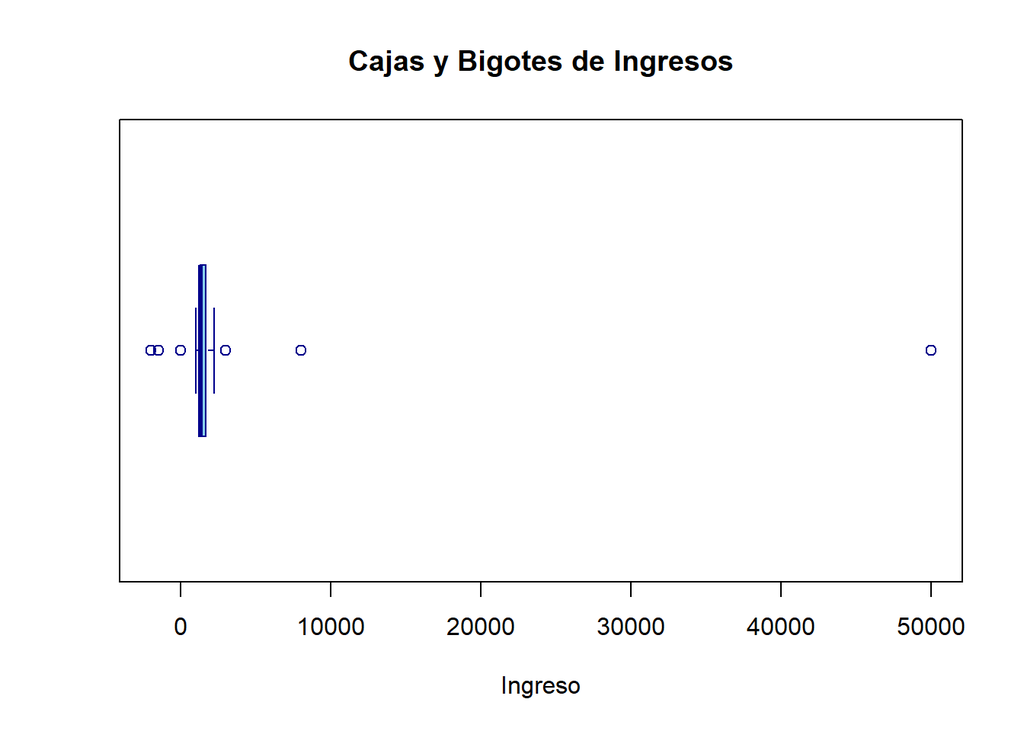

```r
library(ggplot2)

boxplot(
  data$Ingreso,
  horizontal = TRUE,
  col = "skyblue",
  border = "darkblue",
  main = "Cajas y Bigotes de Ingresos",
  xlab = "Ingreso"
)
```

El boxplot de la variable Ingreso muestra una distribución altamente asimétrica hacia la derecha. La mayoría de los ingresos se concentran en valores relativamente bajos, aproximadamente entre 1000 y 2000, lo cual se evidencia por la caja pequeña y cercana al origen. Sin embargo, aparecen varios valores atípicos (outliers), especialmente uno extremadamente alto cercano a 50000, que provoca una gran dispersión en la escala y desplaza visualmente el resto de los datos hacia la izquierda. También se observan algunos ingresos negativos, lo que podría indicar errores de digitación o situaciones particulares en los datos. Debido a estos valores extremos, la media de los ingresos probablemente sea mucho mayor que la mediana, indicando que unos pocos ingresos altos influyen significativamente en el promedio general.

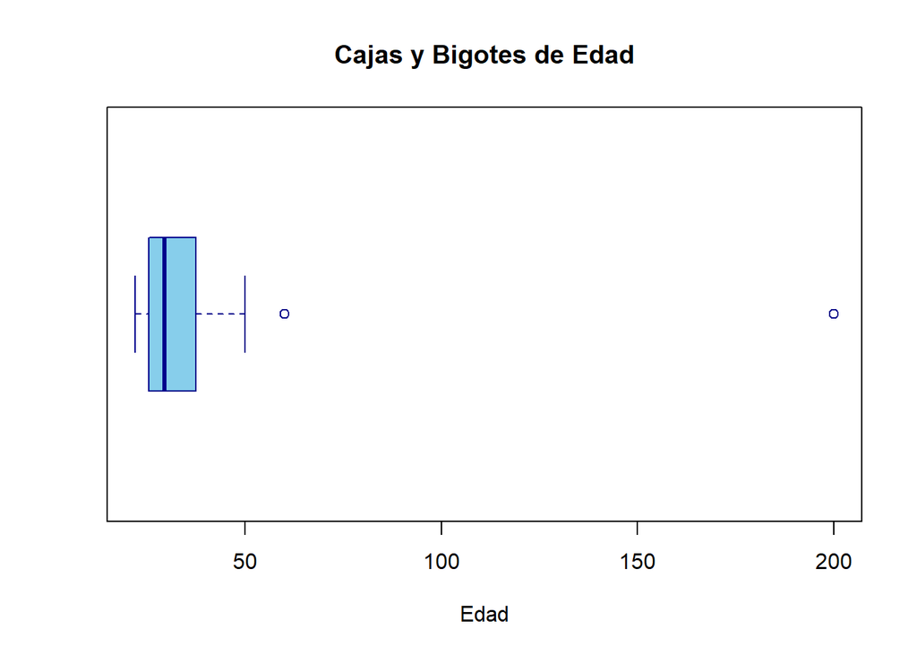

```r
boxplot(
  data$Edad,
  horizontal = TRUE,
  col = "skyblue",
  border = "darkblue",
  main = "Cajas y Bigotes de Edad",
  xlab = "Edad"
)
```

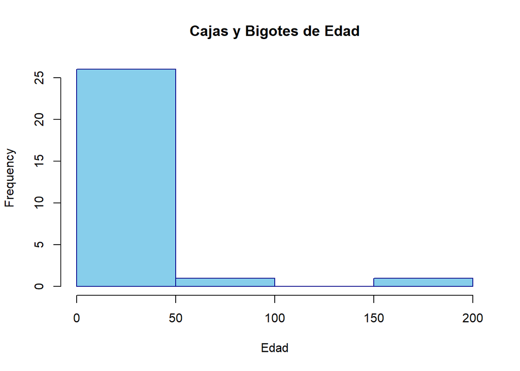

```r
hist(
  data$Edad,
  col = "skyblue",
  border = "darkblue",
  main = "Cajas y Bigotes de Edad",
  xlab = "Edad"
)
```

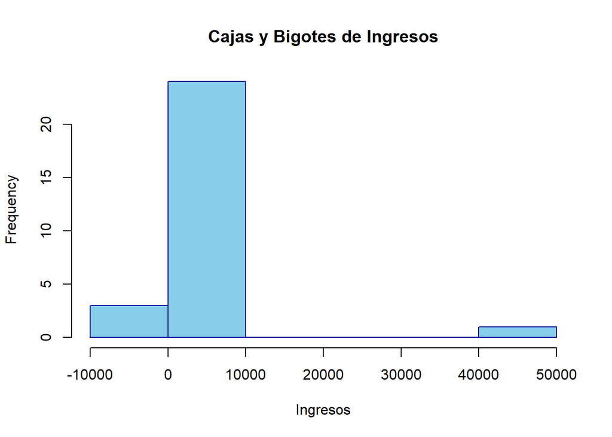

```r
hist(
  data$Ingreso,
  col = "skyblue",
  border = "darkblue",
  main = "Cajas y Bigotes de Ingresos",
  xlab = "Ingresos"
)
```

# 6 5. Limpieza de datos

## 6.1 Valores faltantes

Valores perdidos en todo el data frame

```r
# Número total de datos perdidos en el dataframe
total_na <- sum(is.na(data))

print(paste("Total de datos perdidos:", total_na))
```

```
## [1] "Total de datos perdidos: 4"
```

Total de datos perdidos 4.

Valores faltantes por columnas

```r
library(dplyr)


# Número de datos perdidos por columna
na_por_columna <- colSums(is.na(data))

# Crear un dataframe con los resultados

tabla_na <- data.frame(
  Columna = names(na_por_columna), # obtiene los nombres de las columnas
  Datos_Perdidos = na_por_columna # contiene la cantidad de NA por variable
)

# tabla_na
# Agregar una fila con el total de datos perdidos

tabla_na <- rbind(tabla_na, data.frame(Columna = "Total", Datos_Perdidos = total_na)) # rbind() agrega filas a una tabla, una fila con Total y datos perdidos


#tabla_na

# Ordenar la tabla en orden descendente
tabla_na_ordenada <- tabla_na %>%
  filter(Columna != "Total") %>%  # Excluir la fila "Total"
  arrange(desc(Datos_Perdidos)) %>%  # Ordenar de mayor a menor
  rbind(data.frame(Columna = "Total", Datos_Perdidos = total_na))  # Agregar la fila "Total" al final

tabla_na_ordenada
```

```
##                         Columna Datos_Perdidos
## Edad                       Edad              2
## Ingreso                 Ingreso              2
## ID                           ID              0
## Nombre                   Nombre              0
## Apellido               Apellido              0
## Genero                   Genero              0
## Ciudad                   Ciudad              0
## Profesion             Profesion              0
## Nivel_Educativo Nivel_Educativo              0
## Estado_Civil       Estado_Civil              0
## Hijos                     Hijos              0
## Email                     Email              0
## 1                         Total              4
```

## 6.2 Total datos Duplicados

```r
sum(duplicated(data))
```

```
## [1] 0
```

## 6.3 Mostrar datos duplicados

```r
data[duplicated(data), ]
```

```
##  [1] ID              Nombre          Apellido        Edad
##  [5] Ingreso         Genero          Ciudad          Profesion
##  [9] Nivel_Educativo Estado_Civil    Hijos           Email
## <0 rows> (o 0- extensión row.names)
```

No se observan datos duplicados, sin embargo se debe tener cuidado pues las filas con: ID 1, ID 7, ID 30 son duplicados pues puedes estar en mayúsculas o minúsculas

```r
filas_repetidas <- data[c(1, 7, 30), ]
filas_repetidas
```

```
##    ID Nombre Apellido Edad Ingreso    Genero Ciudad Profesion Nivel_Educativo
## 1   1   Juan    Pérez   25    1200 MASCULINO Bogotá Ingeniero   Universitario
## 7   7   Juan    Pérez   25    1200 MASCULINO Bogotá Ingeniero   Universitario
## 30 30   Juan    Pérez   25    1200 MASCULINO Bogotá Ingeniero   Universitario
##    Estado_Civil Hijos           Email
## 1       SOLTERO     0 juanp@gmail.com
## 7       SOLTERO     0 juanp@gmail.com
## 30      SOLTERO     0 juanp@gmail.com
```

## 6.4 Datos repetidos sin tener en cuenta el ID

Datos sin tener en cuenta la primera columna correspondiente a ID

```r
data_sin <-(data[ , -1])
head(data_sin)
```

```
##   Nombre  Apellido Edad Ingreso    Genero   Ciudad   Profesion Nivel_Educativo
## 1   Juan     Pérez   25    1200 MASCULINO   Bogotá   Ingeniero   Universitario
## 2    Ana     Gómez   30    1500  Femenino Medellín     Abogada Especialización
## 3 Carlos     Lopez   45    3000 MASCULINO     Cali      Medico        Maestría
## 4  María Rodríguez   29      NA  FEMENINO   Bogotá     Docente   Universitario
## 5  Pedro  Martinez   35   -2000 Masculino   bogotá Comerciante       Bachiller
## 6  Luisa Hernandez   NA    1800  FEMENINO     Cali   Ingeniera   Universitario
##   Estado_Civil Hijos               Email
## 1      SOLTERO     0     juanp@gmail.com
## 2       Casada     1 ana.gomez@gmail.com
## 3       CASADO     2   carlosl@gmail.com
## 4      Soltera     0     maria@gmail.com
## 5  UNION LIBRE     3     pedro@gmail.com
## 6      Soltera     0     luisa@gmail.com
```

Averiguar el número total de filas repetidas

```r
sum(duplicated(data_sin))
```

```
## [1] 2
```

Número de filas repetidas dos.

Mostrar las filas repetidas

```r
data_sin[duplicated(data_sin), ]
```

```
##    Nombre Apellido Edad Ingreso    Genero Ciudad Profesion Nivel_Educativo
## 7    Juan    Pérez   25    1200 MASCULINO Bogotá Ingeniero   Universitario
## 30   Juan    Pérez   25    1200 MASCULINO Bogotá Ingeniero   Universitario
##    Estado_Civil Hijos           Email
## 7       SOLTERO     0 juanp@gmail.com
## 30      SOLTERO     0 juanp@gmail.com
```

## 6.5 Eliminar las filas repetidas.

Archivo de eliminando las filas repetidas

```r
# Eliminar filas duplicadas ignorando la columna ID

data_sin <- data[!duplicated(data[ , -1]), ]
head(data_sin)
```

```
##   ID Nombre  Apellido Edad Ingreso    Genero   Ciudad   Profesion
## 1  1   Juan     Pérez   25    1200 MASCULINO   Bogotá   Ingeniero
## 2  2    Ana     Gómez   30    1500  Femenino Medellín     Abogada
## 3  3 Carlos     Lopez   45    3000 MASCULINO     Cali      Medico
## 4  4  María Rodríguez   29      NA  FEMENINO   Bogotá     Docente
## 5  5  Pedro  Martinez   35   -2000 Masculino   bogotá Comerciante
## 6  6  Luisa Hernandez   NA    1800  FEMENINO     Cali   Ingeniera
##   Nivel_Educativo Estado_Civil Hijos               Email
## 1   Universitario      SOLTERO     0     juanp@gmail.com
## 2 Especialización       Casada     1 ana.gomez@gmail.com
## 3        Maestría       CASADO     2   carlosl@gmail.com
## 4   Universitario      Soltera     0     maria@gmail.com
## 5       Bachiller  UNION LIBRE     3     pedro@gmail.com
## 6   Universitario      Soltera     0     luisa@gmail.com
```

Dimensiones de la data sin datos repetidos.

```r
dim(data_sin)
```

```
## [1] 28 12
```

## 6.6 Eliminar datos perdidos

Data sin datos perdidos

```r
# Eliminar filas con valores perdidos (NA)
data_limpia <- na.omit(data_sin)
head(data_limpia)
```

```
##   ID Nombre Apellido Edad Ingreso    Genero   Ciudad   Profesion
## 1  1   Juan    Pérez   25    1200 MASCULINO   Bogotá   Ingeniero
## 2  2    Ana    Gómez   30    1500  Femenino Medellín     Abogada
## 3  3 Carlos    Lopez   45    3000 MASCULINO     Cali      Medico
## 5  5  Pedro Martinez   35   -2000 Masculino   bogotá Comerciante
## 8  8 Andres   Garcia   40   50000 MASCULINO Medellín  Empresario
## 9  9  Sofía     Diaz   22    1100  Femenino     Cali  Estudiante
##   Nivel_Educativo Estado_Civil Hijos               Email
## 1   Universitario      SOLTERO     0     juanp@gmail.com
## 2 Especialización       Casada     1 ana.gomez@gmail.com
## 3        Maestría       CASADO     2   carlosl@gmail.com
## 5       Bachiller  UNION LIBRE     3     pedro@gmail.com
## 8        Maestría       Casado     2    andres@gmail.com
## 9   Universitario      Soltera     0     sofia@gmail.com
```

```r
dim(data_limpia)
```

```
## [1] 24 12
```

24 filas y 12 columnas.

Ahora procedemos a corregir el formato de las categorías, por ejemplo: Femenino, FEMENINO, fEMENIno, algunas palabras tienen tildes otras no, por ejemplo: bogotá, Bogota.

## 6.7 Dejar las variables solo con la primera letra en mayúscula

```r
# Variables cualitativas
vars_cualitativas <- c(
  "Nombre",
  "Apellido",
  "Genero",
  "Ciudad",
  "Profesion",
  "Nivel_Educativo",
  "Estado_Civil",
  "Email"
)
```

```r
# Quitar tildes usando iconv()
data_limpia[vars_cualitativas] <- lapply(
  data_limpia[vars_cualitativas],
  function(x) {
    x <- as.character(x)
    x <- tolower(x)
    x <- iconv(x, from = "UTF-8", to = "ASCII//TRANSLIT")
    paste0(
      toupper(substr(x, 1, 1)),
      substr(x, 2, nchar(x))
    )
  }
)

# Ver resultados
head(data_limpia)
```

```
##   ID Nombre Apellido Edad Ingreso    Genero   Ciudad   Profesion
## 1  1   Juan    Perez   25    1200 Masculino   Bogota   Ingeniero
## 2  2    Ana    Gomez   30    1500  Femenino Medellin     Abogada
## 3  3 Carlos    Lopez   45    3000 Masculino     Cali      Medico
## 5  5  Pedro Martinez   35   -2000 Masculino   Bogota Comerciante
## 8  8 Andres   Garcia   40   50000 Masculino Medellin  Empresario
## 9  9  Sofia     Diaz   22    1100  Femenino     Cali  Estudiante
##   Nivel_Educativo Estado_Civil Hijos               Email
## 1   Universitario      Soltero     0     Juanp@gmail.com
## 2 Especializacion       Casada     1 Ana.gomez@gmail.com
## 3        Maestria       Casado     2   Carlosl@gmail.com
## 5       Bachiller  Union libre     3     Pedro@gmail.com
## 8        Maestria       Casado     2    Andres@gmail.com
## 9   Universitario      Soltera     0     Sofia@gmail.com
```

Verificación de las categorías con las frecuencias correspondientes, de la variable ciudad.

```r
table(data_limpia$Ciudad)
```

```
##
##   Bogota     Cali Medellin
##       10        8        6
```

Verificación de las categorías con las frecuencias correspondientes, de la variable genero.

```r
table(data_limpia$Genero)
```

```
##
##  Femenino Masculino
##        11        13
```

Verificación de las categorías con las frecuencias correspondientes, de la variable profesión.

```r
tabla_profesion <- data.frame(sort(table(data_limpia$Profesion),
                                      decreasing = TRUE))

colnames(tabla_profesion) <- c("Profesion", "Frecuencia")

tabla_profesion
```

```
##        Profesion Frecuencia
## 1      Ingeniero          4
## 2     Estudiante          3
## 3        Abogada          2
## 4  Administrador          2
## 5    Comerciante          2
## 6       Contador          2
## 7     Disenadora          2
## 8        Docente          2
## 9     Empresario          2
## 10     Psicologa          2
## 11        Medico          1
```

Verificación de las categorías con las frecuencias correspondientes, de la variable estado civil.

```r
tabla_estado <- data.frame(sort(table(data_limpia$Estado_Civil),
                                      decreasing = TRUE))

colnames(tabla_estado) <- c("Estado Civil", "Frecuencia")

tabla_estado
```

```
##   Estado Civil Frecuencia
## 1       Casado          8
## 2      Soltera          8
## 3       Casada          3
## 4      Soltero          3
## 5  Union libre          2
```

## 6.8 Cambiar casado y casada a: Casado, y soltero y soltera a: Soltero, en una nueva columna.

Crear una nueva columna denominada Estado_Civil_Limpio en donde:

- casado y casada a: Casado
- Soltero y soltera a: Soltero

```r
data_limpia$Estado_Civil_Limpio <- ifelse(
  tolower(data_limpia$Estado_Civil) %in% c("casado", "casada"),
  "Casado",
  ifelse(
    tolower(data_limpia$Estado_Civil) %in% c("soltero", "soltera"),
    "Soltero",
    data_limpia$Estado_Civil
  )
)
```

Verificación

```r
table(data_limpia$Estado_Civil_Limpio)
```

```
##
##      Casado     Soltero Union libre
##          11          11           2
```

## 6.9 Corrección de errores o inconsistencias

Vamos a verificar los valores de ingresos que no tienen sentido, es decir aquellos valores negativos. Vamos a mirar algunos estadísticos descriptivos para vizualizar estas inconsistencias.

```r
summary(data$Ingreso)
```

```
##    Min. 1st Qu.  Median    Mean 3rd Qu.    Max.    NA's
##   -2000    1200    1325    3200    1625   50000       2
```

Vizualizar el numero de registros con valores negativos o cero, mostrar cuales son los registros con estas inconsistencias.

```r
# Mostrar filas donde Ingreso es negativo
data_limpia[data_limpia$Ingreso <= 0, ]
```

```
##    ID Nombre Apellido Edad Ingreso    Genero Ciudad   Profesion Nivel_Educativo
## 5   5  Pedro Martinez   35   -2000 Masculino Bogota Comerciante       Bachiller
## 12 12  Diego  Ramirez   50       0 Masculino   Cali    Contador   Universitario
## 21 21  Pedro Martinez   35   -1500 Masculino Bogota Comerciante       Bachiller
##    Estado_Civil Hijos           Email Estado_Civil_Limpio
## 5   Union libre     3 Pedro@gmail.com         Union libre
## 12       Casado     2 Diego@gmail.com              Casado
## 21  Union libre     3 Pedro@gmail.com         Union libre
```

Se observa posibles duplicados con error en ingreso el señor “Pedro Martinez”

```r
# Mostrar filas donde Ingreso es negativo o mayor a 100
data_limpia[data_limpia$Edad <= 0 | data_limpia$Edad >100, ]
```

```
##    ID  Nombre Apellido Edad Ingreso    Genero Ciudad  Profesion Nivel_Educativo
## 28 28 Ricardo   Acosta  200    3000 Masculino   Cali Empresario        Maestria
##    Estado_Civil Hijos             Email Estado_Civil_Limpio
## 28       Casado     4 Ricardo@gmail.com              Casado
```

Se presenta un registro con edad de 200 años, lo cual no es consistente.

```r
# Mostrar filas donde Ingreso es negativo o mayor a 100
data_limpia[data_limpia$Hijos < 0 | data_limpia$Hijos > 12, ]
```

```
##  [1] ID                  Nombre              Apellido
##  [4] Edad                Ingreso             Genero
##  [7] Ciudad              Profesion           Nivel_Educativo
## [10] Estado_Civil        Hijos               Email
## [13] Estado_Civil_Limpio
## <0 rows> (o 0- extensión row.names)
```

No se presentan inconsistencias con respecto al número de hijos. Número de hijos negativos o más de 12.

### 6.9.1 Quitar los registros con las inconsistencias encontradas.

```r
data_sin_errores <- data_limpia[
  !(data_limpia$Edad <= 0 | data_limpia$Edad > 100 |
    data_limpia$Ingreso < 0),
]
```

Veamos las dimensiones de la data

```r
dim(data_sin_errores)
```

```
## [1] 21 13
```

Las nuevas diemnsiones son 21 filas (registros) y 13 columnas (variables)

## 6.10 Encontremos valores atípicos en la variable ingresos

## 6.11 Identificación de Valores Atípicos

Los valores atípicos (outliers) son observaciones que presentan un comportamiento inusual respecto al resto de los datos. Estos valores pueden deberse a errores de digitación, problemas en la recolección de datos o variaciones reales dentro de la población estudiada. La detección de valores atípicos es una etapa fundamental del análisis exploratorio, ya que pueden afectar medidas estadísticas como la media, la desviación estándar y los modelos estadísticos.

Uno de los métodos más utilizados para identificar valores atípicos es el criterio del rango intercuartílico (IQR, *Interquartile Range*). Este método se basa en los cuartiles de la distribución:

- **Q1:** primer cuartil (25% de los datos).
- **Q3:** tercer cuartil (75% de los datos).
- **IQR:** diferencia entre Q3 y Q1.

$$IQR = Q3 - Q1$$

A partir del IQR se establecen límites para detectar observaciones extremas:

$$Límite\ inferior = Q1 - 1.5 \times IQR$$

$$Límite\ superior = Q3 + 1.5 \times IQR$$

Los datos que se encuentran por debajo del límite inferior o por encima del límite superior se consideran valores atípicos.

### 6.11.1 En R

```r
# Calcular cuartiles
Q1 <- quantile(data_sin_errores$Ingreso, 0.25 )
Q3 <- quantile(data_sin_errores$Ingreso, 0.75) # data_sin_errores$Ingreso, 0.75, na.rm = TRUE si no se han quitado los valores perdidos.

# Calcular rango intercuartílico
IQR_valor <- IQR(data_sin_errores$Ingreso)

# Definir límites
limite_inferior <- Q1 - 1.5 * IQR_valor
limite_superior <- Q3 + 1.5 * IQR_valor

# Mostrar valores atípicos
valores_atipicos <- data_sin_errores[
  data_sin_errores$Ingreso < limite_inferior |
  data_sin_errores$Ingreso > limite_superior,
]

valores_atipicos
```

```
##    ID Nombre Apellido Edad Ingreso    Genero   Ciudad     Profesion
## 3   3 Carlos    Lopez   45    3000 Masculino     Cali        Medico
## 8   8 Andres   Garcia   40   50000 Masculino Medellin    Empresario
## 12 12  Diego  Ramirez   50       0 Masculino     Cali      Contador
## 15 15 Miguel   Ortega   60    8000 Masculino     Cali Administrador
##    Nivel_Educativo Estado_Civil Hijos             Email Estado_Civil_Limpio
## 3         Maestria       Casado     2 Carlosl@gmail.com              Casado
## 8         Maestria       Casado     2  Andres@gmail.com              Casado
## 12   Universitario       Casado     2   Diego@gmail.com              Casado
## 15        Maestria       Casado     3  Miguel@gmail.com              Casado
```

```r
data_sin_errores <- data_sin_errores[
  !(data_sin_errores$Ingreso < limite_inferior |
  data_sin_errores$Ingreso > limite_superior),
]
```

```r
table(data_sin_errores$Ciudad)
```

```
##
##   Bogota     Cali Medellin
##        8        4        5
```

```r
summary(data_sin_errores$Ingreso)
```

```
##    Min. 1st Qu.  Median    Mean 3rd Qu.    Max.
##    1000    1200    1300    1379    1500    2200
```

```r
# Cantidad de datos perdidos por columna
colSums(is.na(data_sin_errores))
```

```
##                  ID              Nombre            Apellido                Edad
##                   0                   0                   0                   0
##             Ingreso              Genero              Ciudad           Profesion
##                   0                   0                   0                   0
##     Nivel_Educativo        Estado_Civil               Hijos               Email
##                   0                   0                   0                   0
## Estado_Civil_Limpio
##                   0
```

```r
dim(data_sin_errores)
```

```
## [1] 17 13
```

```r
# Calcular estadísticos
estadisticos <- data.frame(
  Estadístico = c("Media", "Mediana", "Desviación Estándar", "Mínimo", "Máximo", "Q1 (25%)", "Q2 (50%)", "Q3 (75%)"),
  Valor = c(
    mean(data_sin_errores$Ingreso),
    median(data_sin_errores$Ingreso),
    sd(data_sin_errores$Ingreso),
    min(data_sin_errores$Ingreso),
    max(data_sin_errores$Ingreso),
    quantile(data_sin_errores$Ingreso, probs = 0.25),
    quantile(data_sin_errores$Ingreso, probs = 0.50),
    quantile(data_sin_errores$Ingreso, probs = 0.75)
  )
)

estadisticos
```

```
##           Estadístico     Valor
## 1               Media 1379.4118
## 2             Mediana 1300.0000
## 3 Desviación Estándar  280.0998
## 4              Mínimo 1000.0000
## 5              Máximo 2200.0000
## 6            Q1 (25%) 1200.0000
## 7            Q2 (50%) 1300.0000
## 8            Q3 (75%) 1500.0000
```

## 6.12 Estandarización de Variables

La estandarización es una técnica de transformación de datos utilizada en estadística y análisis de datos para convertir una variable numérica a una escala común. Este procedimiento consiste en centrar los datos respecto a su media y escalarlos utilizando su desviación estándar.

La fórmula de estandarización está dada por:

$$Z = \frac{X - \mu}{\sigma}$$

donde:

- $X$ representa el valor original de la variable,
- $\mu$ corresponde a la media de la variable,
- $\sigma$ representa la desviación estándar,
- $Z$ es el valor estandarizado.

Después de la transformación, la nueva variable presenta una media aproximada de cero y una desviación estándar cercana a uno.

### 6.12.1 ¿Por qué es necesario estandarizar variables?

La estandarización es necesaria cuando las variables del conjunto de datos se encuentran en diferentes escalas de medición. Por ejemplo, una variable de ingresos puede tomar valores en miles, mientras que una variable de edad puede variar entre 18 y 80. Si no se realiza una transformación previa, las variables con magnitudes más grandes pueden dominar los resultados del análisis y generar interpretaciones sesgadas.

Este procedimiento es especialmente importante en técnicas estadísticas y algoritmos de aprendizaje automático que dependen de distancias o magnitudes numéricas, tales como:

- Regresión lineal y logística
- Clustering (K-means)
- Análisis de Componentes Principales (PCA)
- Redes neuronales
- Máquinas de soporte vectorial (SVM)

La estandarización permite:

- Comparar variables en una misma escala,
- Reducir el efecto de diferencias de magnitud,
- Mejorar la estabilidad numérica de los modelos,
- Facilitar la interpretación estadística,
- Optimizar el desempeño de algoritmos predictivos.

### 6.12.2 En R

```r
data_sin_errores$Ingreso_est <- scale(data_sin_errores$Ingreso)
```

Verificar la estandarización

```r
summary(data_sin_errores$Ingreso_est)
```

```
##        V1
##  Min.   :-1.3546
##  1st Qu.:-0.6405
##  Median :-0.2835
##  Mean   : 0.0000
##  3rd Qu.: 0.4305
##  Max.   : 2.9296
```

```r
dim(data_sin_errores)
```

```
## [1] 17 14
```

## 6.13 Normalización Min-Max y Transformación $(x - \min)/( \max - \min)$

La transformación Min-Max es una técnica de escalamiento utilizada para llevar los valores de una variable numérica a un rango específico, generalmente entre 0 y 1. Su fórmula más utilizada es:

$$X_{norm} = \frac{X - X_{min}}{X_{max} - X_{min}}$$

donde:

- $X$ es el valor original,
- $X_{min}$ es el valor mínimo de la variable,
- $X_{max}$ es el valor máximo de la variable,
- $X_{norm}$ es el valor normalizado.

Este procedimiento conserva la distribución original de los datos, pero cambia su escala.

## 6.14 ¿Cuándo se utiliza la normalización Min-Max?

La normalización Min-Max se utiliza principalmente cuando:

- Se requiere que todas las variables estén en el mismo rango,
- Los algoritmos son sensibles a las magnitudes de los datos,
- Se desea preservar la relación proporcional entre los valores,
- No existen valores atípicos extremos significativos.

Es ampliamente utilizada en:

- Redes neuronales,
- Deep Learning,
- Algoritmos basados en distancia,
- Procesamiento de imágenes,
- Sistemas de recomendación,
- Optimización matemática.

## 6.15 Diferencia entre Estandarización y Normalización

| Técnica | Resultado | Uso principal |
| --- | --- | --- |
| Estandarización | Media = 0, desviación = 1 | Modelos estadísticos y ML |
| Min-Max | Valores entre 0 y 1 | Redes neuronales y escalamiento |

## 6.16 ¿Qué significa $(\max - \min)/(\max + \min)$?

La expresión:

$$\frac{\max - \min}{\max + \min}$$

no corresponde a una normalización estándar de datos. Esta fórmula suele utilizarse como una medida relativa de variación o contraste entre valores extremos.

Puede aparecer en contextos como:

- Procesamiento de señales,
- Índices de contraste,
- Análisis de variabilidad,
- Física e ingeniería,
- Procesamiento de imágenes.

Su interpretación consiste en medir qué tan grande es la diferencia entre el valor máximo y mínimo respecto al tamaño total de ambos.

### 6.16.1 En R

```r
# Normalización Min-Max
data_sin_errores$Ingreso_norm <- (
 data_sin_errores$Ingreso - min(data_sin_errores$Ingreso)
) / (
  max(data_sin_errores$Ingreso) -
  min(data_sin_errores$Ingreso)
)
```

```r
min(data_sin_errores$Ingreso_norm)
```

```
## [1] 0
```

```r
max(data_sin_errores$Ingreso_norm)
```

```
## [1] 1
```

## 6.17 Exportar datos

Exportar como archivo Excel al proyecto en la carpeta denominada Resultados

```r
library(writexl)

write_xlsx(data_sin_errores,
           "C:\\Users\\Jairo\\Desktop\\Clase_1_especializacion\\Resultados\\data_listos.xlsx")
```